Librerias

```python
import os
os.chdir('C://Users//jaag2//OneDrive//PuraVidaAnalytics//00 - Clientes//03 - Texas Tech//07 - Cursos//01 - No Supervisado//03 - Estadistica')
```

```python
import pandas as pd
import numpy as np
```

# Leer Datos

```python
carsdf = pd.read_csv("cars.csv")
carsdf
```

|  | manufacturer_name | model_name | transmission | color | odometer_value | year_produced | engine_fuel | engine_has_gas | engine_type | engine_capacity | ... | feature_1 | feature_2 | feature_3 | feature_4 | feature_5 | feature_6 | feature_7 | feature_8 | feature_9 | duration_listed |
| --- | --- | --- | --- | --- | --- | --- | --- | --- | --- | --- | --- | --- | --- | --- | --- | --- | --- | --- | --- | --- | --- |
| 0 | Subaru | Outback | automatic | silver | 190000 | 2010 | gasoline | False | gasoline | 2.5 | ... | True | True | True | False | True | False | True | True | True | 16 |
| 1 | Subaru | Outback | automatic | blue | 290000 | 2002 | gasoline | False | gasoline | 3.0 | ... | True | False | False | True | True | False | False | False | True | 83 |
| 2 | Subaru | Forester | automatic | red | 402000 | 2001 | gasoline | False | gasoline | 2.5 | ... | True | False | False | False | False | False | False | True | True | 151 |
| 3 | Subaru | Impreza | mechanical | blue | 10000 | 1999 | gasoline | False | gasoline | 3.0 | ... | False | False | False | False | False | False | False | False | False | 86 |
| 4 | Subaru | Legacy | automatic | black | 280000 | 2001 | gasoline | False | gasoline | 2.5 | ... | True | False | True | True | False | False | False | False | True | 7 |
| ... | ... | ... | ... | ... | ... | ... | ... | ... | ... | ... | ... | ... | ... | ... | ... | ... | ... | ... | ... | ... | ... |
| 38526 | Chrysler | 300 | automatic | silver | 290000 | 2000 | gasoline | False | gasoline | 3.5 | ... | True | False | False | True | True | False | False | True | True | 301 |
| 38527 | Chrysler | PT Cruiser | mechanical | blue | 321000 | 2004 | diesel | False | diesel | 2.2 | ... | True | False | False | True | True | False | False | True | True | 317 |
| 38528 | Chrysler | 300 | automatic | blue | 777957 | 2000 | gasoline | False | gasoline | 3.5 | ... | True | False | False | True | True | False | False | True | True | 369 |
| 38529 | Chrysler | PT Cruiser | mechanical | black | 20000 | 2001 | gasoline | False | gasoline | 2.0 | ... | True | False | False | False | False | False | False | False | True | 490 |
| 38530 | Chrysler | Voyager | automatic | silver | 297729 | 2000 | gasoline | False | gasoline | 2.4 | ... | False | False | False | False | False | False | False | False | True | 632 |

38531 rows × 30 columns

```python
carsdf.dtypes # Tipos de Datos
```

```
manufacturer_name     object
model_name            object
transmission          object
color                 object
odometer_value         int64
year_produced          int64
engine_fuel           object
engine_has_gas          bool
engine_type           object
engine_capacity      float64
body_type             object
has_warranty            bool
state                 object
drivetrain            object
price_usd            float64
is_exchangeable         bool
location_region       object
number_of_photos       int64
up_counter             int64
feature_0               bool
feature_1               bool
feature_2               bool
feature_3               bool
feature_4               bool
feature_5               bool
feature_6               bool
feature_7               bool
feature_8               bool
feature_9               bool
duration_listed        int64
dtype: object
```

Generar un conjunto de estadísticos descriptivos del dataset:

```python
carsdf.describe()
```

|  | odometer_value | year_produced | engine_capacity | price_usd | number_of_photos | up_counter | duration_listed |
| --- | --- | --- | --- | --- | --- | --- | --- |
| count | 38531.000000 | 38531.000000 | 38521.000000 | 38531.000000 | 38531.000000 | 38531.000000 | 38531.000000 |
| mean | 248864.638447 | 2002.943734 | 2.055161 | 6639.971021 | 9.649062 | 16.306091 | 80.577249 |
| std | 136072.376530 | 8.065731 | 0.671178 | 6428.152018 | 6.093217 | 43.286933 | 112.826569 |
| min | 0.000000 | 1942.000000 | 0.200000 | 1.000000 | 1.000000 | 1.000000 | 0.000000 |
| 25% | 158000.000000 | 1998.000000 | 1.600000 | 2100.000000 | 5.000000 | 2.000000 | 23.000000 |
| 50% | 250000.000000 | 2003.000000 | 2.000000 | 4800.000000 | 8.000000 | 5.000000 | 59.000000 |
| 75% | 325000.000000 | 2009.000000 | 2.300000 | 8990.000000 | 12.000000 | 16.000000 | 91.000000 |
| max | 1000000.000000 | 2019.000000 | 8.000000 | 50000.000000 | 86.000000 | 1861.000000 | 2232.000000 |

# Medidas de Tendencia Central

```python
carsdf.price_usd.mean()
```

```
6639.971021255613
```

```python
carsdf['price_usd'].mean()
```

```
6639.971021255613
```

```python
carsdf['price_usd'].quantile(0.25)
```

```
2100.0
```

```python
carsdf['price_usd'].std()
```

```
6428.152018202915
```

```python
carsdf['price_usd'].quantile(.50) #Mediana
```

```
4800.0
```

```python
carsdf['price_usd'].min()
```

```
1.0
```

```python
carsdf['price_usd'].max()
```

```
50000.0
```

```python
carsdf['price_usd'].mode()
```

```
0    1500.0
Name: price_usd, dtype: float64
```

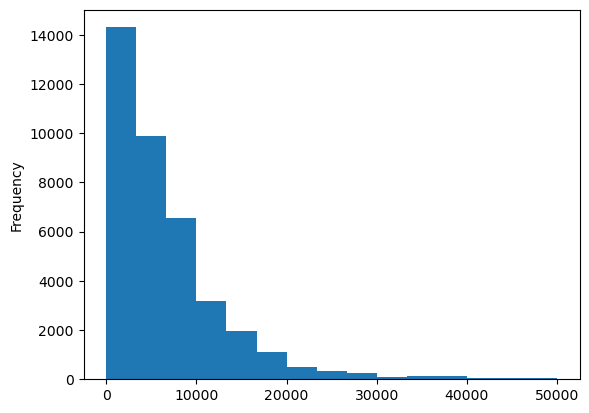

```python
carsdf['price_usd'].plot.hist(bins=15)
```

```python
#Rango = valor max - valor min
rango = carsdf['price_usd'].max() - carsdf['price_usd'].min()
rango
```

```
49999.0
```

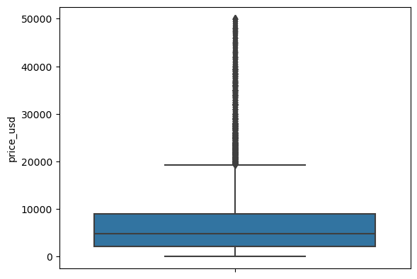

```python
import seaborn as sns
sns.boxplot(
    y     = 'price_usd',
    data  = carsdf
)
```

```python
#Quartiles
median = carsdf['price_usd'].median()
Q1 = carsdf['price_usd'].quantile(q=0.25) #toma el primer 25% de todos los datos
Q3 = carsdf['price_usd'].quantile(q=0.75)
min_val = carsdf['price_usd'].quantile(q=0)
max_val = carsdf['price_usd'].quantile(q=1)
print(min_val, Q1, median, Q3, max_val)
```

```
1.0 2100.0 4800.0 8990.0 50000.0
```

```python
iqr = Q3 - Q1
iqr
```

```
6890.0
```

## Límites para detección de outliers (con datos simétricamente distribuídos)

```python
minlimit = Q1 - 1.5*iqr
maxlimit = Q3 + 1.5*iqr
print(minlimit, maxlimit)
```

```
-8235.0 19325.0
```

```python
minlimit
```

```
-8235.0
```

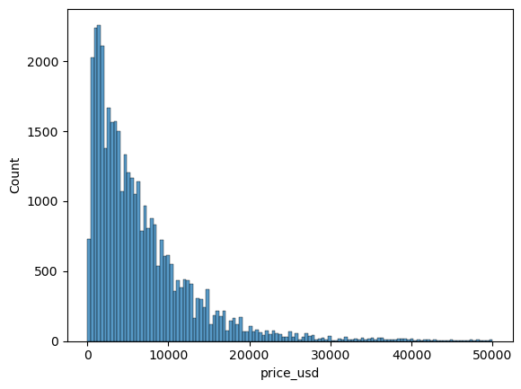

```python
sns.histplot(carsdf['price_usd'])
```

**Nota 1:** El valor es negativo porque se está aplicando una ecuación de una distribución simética a una no simétrica.

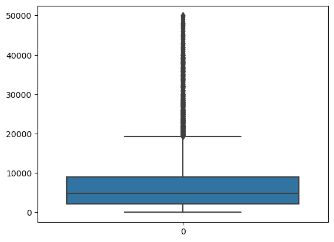

```python
sns.boxplot(carsdf['price_usd'])
```

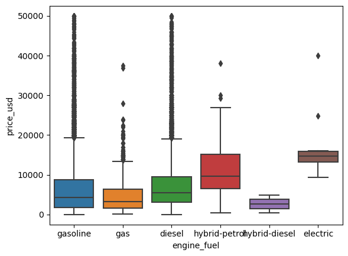

```python
sns.boxplot(x='engine_fuel', y='price_usd', data=carsdf)
```

```python
carsdf.dtypes
```

```
manufacturer_name     object
model_name            object
transmission          object
color                 object
odometer_value         int64
year_produced          int64
engine_fuel           object
engine_has_gas          bool
engine_type           object
engine_capacity      float64
body_type             object
has_warranty            bool
state                 object
drivetrain            object
price_usd            float64
is_exchangeable         bool
location_region       object
number_of_photos       int64
up_counter             int64
feature_0               bool
feature_1               bool
feature_2               bool
feature_3               bool
feature_4               bool
feature_5               bool
feature_6               bool
feature_7               bool
feature_8               bool
feature_9               bool
duration_listed        int64
dtype: object
```

```python
carsdf.select_dtypes(include=['float64', 'int64'])
```

|  | odometer_value | year_produced | engine_capacity | price_usd | number_of_photos | up_counter | duration_listed |
| --- | --- | --- | --- | --- | --- | --- | --- |
| 0 | 190000 | 2010 | 2.5 | 10900.00 | 9 | 13 | 16 |
| 1 | 290000 | 2002 | 3.0 | 5000.00 | 12 | 54 | 83 |
| 2 | 402000 | 2001 | 2.5 | 2800.00 | 4 | 72 | 151 |
| 3 | 10000 | 1999 | 3.0 | 9999.00 | 9 | 42 | 86 |
| 4 | 280000 | 2001 | 2.5 | 2134.11 | 14 | 7 | 7 |
| ... | ... | ... | ... | ... | ... | ... | ... |
| 38526 | 290000 | 2000 | 3.5 | 2750.00 | 5 | 85 | 301 |
| 38527 | 321000 | 2004 | 2.2 | 4800.00 | 4 | 20 | 317 |
| 38528 | 777957 | 2000 | 3.5 | 4300.00 | 3 | 63 | 369 |
| 38529 | 20000 | 2001 | 2.0 | 4000.00 | 7 | 156 | 490 |
| 38530 | 297729 | 2000 | 2.4 | 3200.00 | 4 | 73 | 632 |

38531 rows × 7 columns

```python
corr_matrix = carsdf.select_dtypes(include=['float64', 'int64']).corr(method='pearson')
```

```python
corr_matrix
```

|  | odometer_value | year_produced | engine_capacity | price_usd | number_of_photos | up_counter | duration_listed |
| --- | --- | --- | --- | --- | --- | --- | --- |
| odometer_value | 1.000000 | -0.488679 | 0.105704 | -0.421204 | -0.143708 | -0.020961 | -0.000428 |
| year_produced | -0.488679 | 1.000000 | 0.005059 | 0.705511 | 0.258180 | 0.007945 | -0.017001 |
| engine_capacity | 0.105704 | 0.005059 | 1.000000 | 0.296597 | 0.106691 | 0.079152 | 0.080081 |
| price_usd | -0.421204 | 0.705511 | 0.296597 | 1.000000 | 0.316859 | 0.057382 | 0.033524 |
| number_of_photos | -0.143708 | 0.258180 | 0.106691 | 0.316859 | 1.000000 | 0.073891 | -0.028255 |
| up_counter | -0.020961 | 0.007945 | 0.079152 | 0.057382 | 0.073891 | 1.000000 | 0.698116 |
| duration_listed | -0.000428 | -0.017001 | 0.080081 | 0.033524 | -0.028255 | 0.698116 | 1.000000 |

```python
import matplotlib.pyplot as plt
```

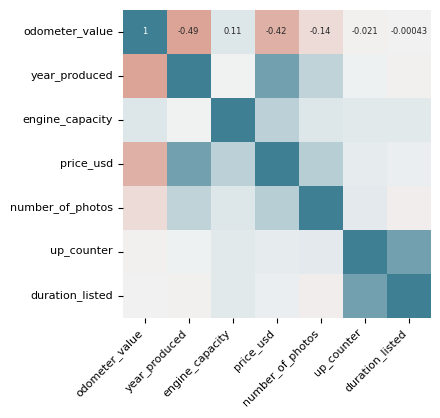

```python
fig, ax = plt.subplots(nrows=1, ncols=1, figsize=(4, 4))

sns.heatmap(
    corr_matrix,
    annot     = True,
    cbar      = False,
    annot_kws = {"size": 6},
    vmin      = -1,
    vmax      = 1,
    center    = 0,
    cmap      = sns.diverging_palette(20, 220, n=200),
    square    = True,
    ax        = ax
)
ax.set_xticklabels(
    ax.get_xticklabels(),
    rotation = 45,
    horizontalalignment = 'right',
)

ax.tick_params(labelsize = 8)
```

# Tipos de escalamiento

## Lineal

**Min-max:** hace una transformación para que los datos entren en el rango [-1, 1] o [0,1] por medio de una fórmula. Es uno de los más usados. Funciona mejor para datos uniformemente distribuidos.

**Z-Score:** es uno de los más comunes porque está basado en el promedio y desviación estándar. Funciona mejor para datos distribuidos "normalmente" (forma de campana de Gauss).

```python
X = carsdf['price_usd']
```

```python
X
```

```
0        10900.00
1         5000.00
2         2800.00
3         9999.00
4         2134.11
           ...
38526     2750.00
38527     4800.00
38528     4300.00
38529     4000.00
38530     3200.00
Name: price_usd, Length: 38531, dtype: float64
```

```python
Z_X = (X - X.mean())/X.std()
```

```python
Z_X
```

```
0        0.662714
1       -0.255123
2       -0.597368
3        0.522550
4       -0.700957
           ...
38526   -0.605146
38527   -0.286236
38528   -0.364019
38529   -0.410689
38530   -0.535142
Name: price_usd, Length: 38531, dtype: float64
```

```python
Z_X.mean()
```

```
-6.78621698787254e-17
```

```python
Z_X.std()
```

```
1.000000000000016
```

```python
MM_X = (X-X.min())/(X.max() - X.min())
```

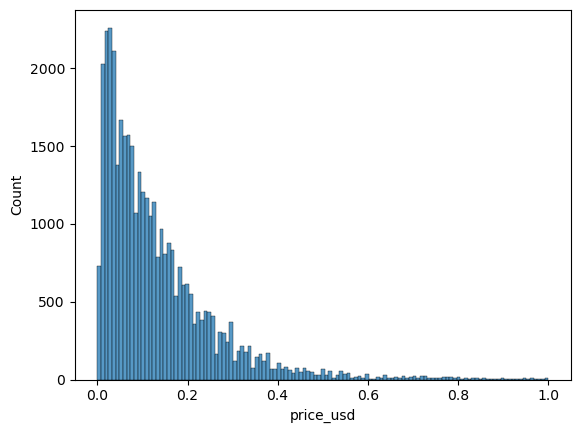

```python
sns.histplot(MM_X)
```

```python
MM2_X = (2*X-X.min()-X.max())/(X.max() - X.min())
```

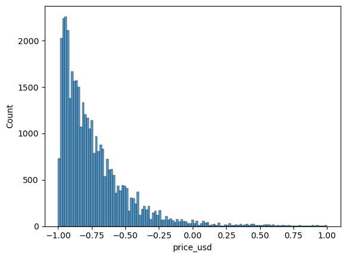

```python
sns.histplot(MM2_X)
```

## Transformaciones no lineales en Python

```python
X_es = X/10000
```

```python
X_tan = np.tanh(X_es)
```

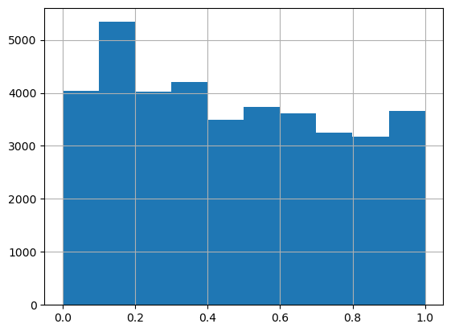

```python
X_tan.hist()
```

# Procesamiento para variables categóricas

**Dummy:** es la representación más compacta que se puede tener de los datos. Es mejor usarla cuando los inputs son variables linealmente independientes (no tienen un grado de correlación significativo). Es decir, las cuando se sabe que las categorías son independientes entre sí. **One-hot:** es más general. Permite incluir categorías que no estaban en el dataset inicialmente. De forma que si se filtra una categoría que no estaba incluida, igual se pueda representar numéricamente.

```python
ZZ = pd.get_dummies(carsdf['engine_type'])
```

```python
ZZ
```

|  | diesel | electric | gasoline |
| --- | --- | --- | --- |
| 0 | False | False | True |
| 1 | False | False | True |
| 2 | False | False | True |
| 3 | False | False | True |
| 4 | False | False | True |
| ... | ... | ... | ... |
| 38526 | False | False | True |
| 38527 | True | False | False |
| 38528 | False | False | True |
| 38529 | False | False | True |
| 38530 | False | False | True |

38531 rows × 3 columns

```python
import sklearn.preprocessing as preprocessing

encoder = preprocessing.OneHotEncoder(handle_unknown='ignore')
```

```python
tmp = carsdf['engine_type'].unique()
```

```python
tmp
```

```
array(['gasoline', 'diesel', 'electric'], dtype=object)
```

```python
encoder.fit(carsdf[['engine_type']].values)
```

```
OneHotEncoder(handle_unknown='ignore')
```

```python
encoder
```

```
OneHotEncoder(handle_unknown='ignore')
```

```python
encoder.transform([['gasoline'],['diesel'], ['aceite'],['agua']]).toarray()
```

```
array([[0., 0., 1.],
       [1., 0., 0.],
       [0., 0., 0.],
       [0., 0., 0.]])
```

```python
encoder.transform([['gasoline'],['diesel'], ['aceite']]).toarray()
```

```
array([[0., 0., 1.],
       [1., 0., 0.],
       [0., 0., 0.]])
```

# Álgebra Lineal aplicada a la matriz de correlaciones

```python
corr_matrix
```

|  | odometer_value | year_produced | engine_capacity | price_usd | number_of_photos | up_counter | duration_listed |
| --- | --- | --- | --- | --- | --- | --- | --- |
| odometer_value | 1.000000 | -0.488679 | 0.105704 | -0.421204 | -0.143708 | -0.020961 | -0.000428 |
| year_produced | -0.488679 | 1.000000 | 0.005059 | 0.705511 | 0.258180 | 0.007945 | -0.017001 |
| engine_capacity | 0.105704 | 0.005059 | 1.000000 | 0.296597 | 0.106691 | 0.079152 | 0.080081 |
| price_usd | -0.421204 | 0.705511 | 0.296597 | 1.000000 | 0.316859 | 0.057382 | 0.033524 |
| number_of_photos | -0.143708 | 0.258180 | 0.106691 | 0.316859 | 1.000000 | 0.073891 | -0.028255 |
| up_counter | -0.020961 | 0.007945 | 0.079152 | 0.057382 | 0.073891 | 1.000000 | 0.698116 |
| duration_listed | -0.000428 | -0.017001 | 0.080081 | 0.033524 | -0.028255 | 0.698116 | 1.000000 |

```python
from numpy.linalg import eig
```

```python
w,v=eig(corr_matrix)
```

```python
w
```

```
array([2.26276437, 1.71228239, 1.12619392, 0.83873606, 0.53102881,
       0.23486557, 0.29412887])
```

```python
w.sum()
```

```
7.000000000000007
```

```python
w # valores propios
```

```
array([2.26276437, 1.71228239, 1.12619392, 0.83873606, 0.53102881,
       0.23486557, 0.29412887])
```

```python
w
```

```
array([2.26276437, 1.71228239, 1.12619392, 0.83873606, 0.53102881,
       0.23486557, 0.29412887])
```

```python
porc_varianza = w/w.sum()
```

```python
porc_varianza
```

```
array([0.32325205, 0.24461177, 0.16088485, 0.11981944, 0.07586126,
       0.03355222, 0.04201841])
```

```python
porc_varianza
```

```
array([0.32325205, 0.24461177, 0.16088485, 0.11981944, 0.07586126,
       0.03355222, 0.04201841])
```

```python
porc_varianza.sum()
```

```
0.9999999999999999
```

```python
V_pd = pd.DataFrame.from_records(v)
```

```python
V_pd.T.dot(V_pd)
```

|  | 0 | 1 | 2 | 3 | 4 | 5 | 6 |
| --- | --- | --- | --- | --- | --- | --- | --- |
| 0 | 1.000000e+00 | -1.352229e-16 | -3.328643e-16 | 8.855268e-17 | 6.918030e-17 | 9.916572e-17 | 5.706270e-17 |
| 1 | -1.352229e-16 | 1.000000e+00 | 4.073029e-16 | -6.527008e-17 | -6.617097e-16 | 1.877511e-16 | -4.578607e-16 |
| 2 | -3.328643e-16 | 4.073029e-16 | 1.000000e+00 | 1.627564e-16 | 1.207682e-16 | -8.315955e-17 | -1.785732e-16 |
| 3 | 8.855268e-17 | -6.527008e-17 | 1.627564e-16 | 1.000000e+00 | -7.056217e-16 | -1.371748e-16 | 5.362632e-16 |
| 4 | 6.918030e-17 | -6.617097e-16 | 1.207682e-16 | -7.056217e-16 | 1.000000e+00 | -3.246695e-16 | 8.951776e-17 |
| 5 | 9.916572e-17 | 1.877511e-16 | -8.315955e-17 | -1.371748e-16 | -3.246695e-16 | 1.000000e+00 | 9.615936e-16 |
| 6 | 5.706270e-17 | -4.578607e-16 | -1.785732e-16 | 5.362632e-16 | 8.951776e-17 | 9.615936e-16 | 1.000000e+00 |